# W3_Notes

(Hint: Treatment == “chilled” & conc == 250)

```r
?CO2
```

```
## starting httpd help server ... done
```

```r
View(CO2)

library(tidyverse) #loads the filter(...) function

CO2.chilled.250 <- filter(CO2, Treatment == "chilled"& conc == 250)

CO2.chilled.250 %>%
  group_by(Type) %>%
  summarise(mean(uptake))
```

```
## # A tibble: 2 x 2
##   Type        `mean(uptake)`
##   <fct>                <dbl>
## 1 Quebec                34.5
## 2 Mississippi           16.1
```

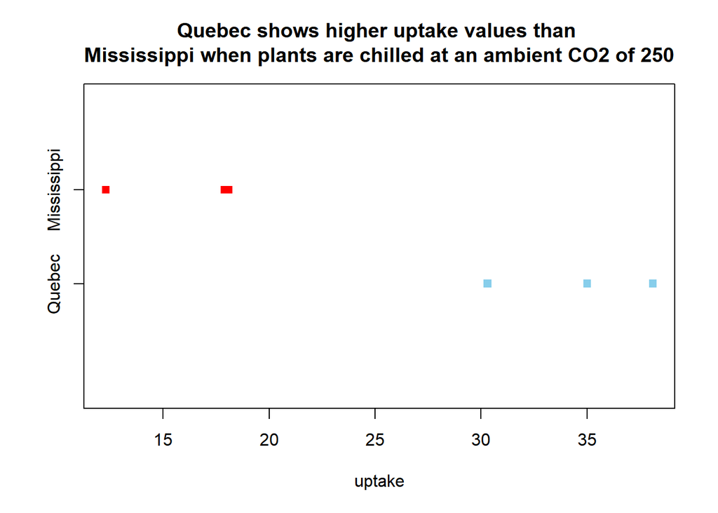

```r
stripchart(uptake ~ Type,
           data = CO2.chilled.250,
           col = c('skyblue', 'red'),
           pch = 15,
           ylim = c(-.2, 3),
           method = "stack",
           main = "Quebec shows higher uptake values than \nMississippi when plants are chilled at an ambient CO2 of 250")
```

These results are based on a small sample of Mississippi and Quebec plants. The question that remains is whether or not this pattern holds for ALL Mississippi and Quebec plants, or if it was just a figment of this sample of data.

To determine if we should conclude that this pattern holds for the full population, conduct an appropriate hypothesis test for the hypotheses:

H0:μMiss−μQueb=0 Ha:μMiss−μQueb≠0 where μMiss represents the (unknown) true mean CO2 uptake of ALL Mississippi plants that are chilled at a concentration of 250 and μQueb represents the true (unkown) mean CO2 uptake of ALL Quebec plants that are chilled at a concentration of 250.

Report the test statistic, the parametric distribution being used for the test statistic (including degrees of freedom if appropriate), and p-value of the test.

```r
t.test(uptake ~ Type,
       data = CO2.chilled.250,
       mu = 0,
       alternative = "two.sided",
       conf.level = .95)
```

```
##
##  Welch Two Sample t-test
##
## data:  uptake by Type
## t = 6.2075, df = 3.8818, p-value = 0.003782
## alternative hypothesis: true difference in means is not equal to 0
## 95 percent confidence interval:
##  10.05213 26.68120
## sample estimates:
##      mean in group Quebec mean in group Mississippi
##                  34.46667                  16.10000
```

Make a Q-Q Plot to determine if the distribution is normal

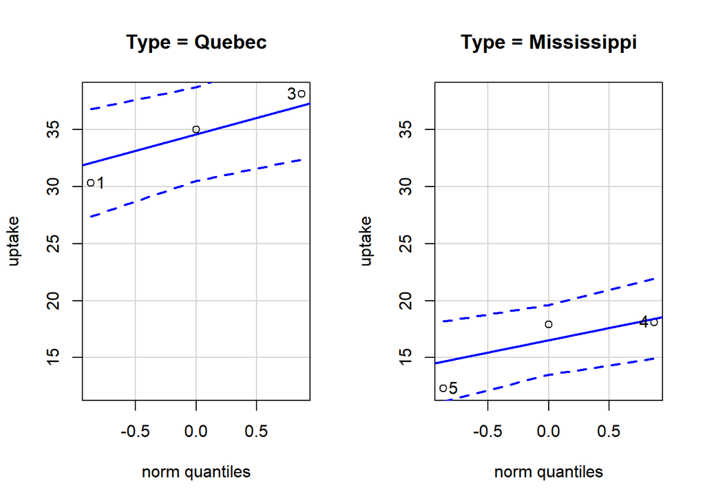

```r
qqPlot(uptake ~ Type, data = CO2.chilled.250)
```